# Análisis de Supervivencia

[figure not shown]

[figure not shown]

[figure not shown]

[figure not shown]

# Introducción

### **¿Qué es el Análisis de Supervivencia?**

El análisis de supervivencia constituye una herramienta estadística para estudiar el tiempo transcurrido hasta la ocurrencia de un evento de interés en diferentes disciplinas: se conoce como “modelos de duración” en ciencia política y economía, “modelos de riesgo” en bioestadística, y “modelos de tiempo hasta el fallo” en ingeniería.

Los datos de supervivencia, también conocidos como datos de tiempo hasta el evento, requieren un conjunto especial de métodos estadísticos por el fenómeno de **la censura**, que se produce cuando el evento de interés no se observa para algunos sujetos durante el período de estudio. Por ejemplo, esto podría corresponder a pacientes que abandonan el seguimiento o cuyo tratamiento se interrumpe antes de observar la progresión de la enfermedad.

*Censura: La censura se produce cuando al final del seguimiento, algunos de los individuos no han tenido el evento de interés, y por lo tanto su verdadero tiempo hasta el evento es desconocido.*

En el contexto biomédico, el análisis de supervivencia modela la distribución temporal de eventos como la muerte, recaída de enfermedades o fallo terapéutico. La variable principal es el tiempo hasta el evento, definido como el intervalo entre un punto de origen (diagnóstico, inicio de tratamiento) y la ocurrencia del evento o la última observación (censurada).

Para abordar esta complejidad añadida, se utiliza el **método de Kaplan-Meier**, un método no paramétrico que incorpora la información parcial de los casos censurados.

Suele expresarse mediante la probabilidad de supervivencia (**survival probability**), que es la probabilidad de que el suceso de interés no haya ocurrido en una duración $t$.

La estimación de Kaplan-Meier se construye mediante el producto de las probabilidades condicionales de supervivencia en cada tiempo observado:
$$\hat{S}(t) = \prod_{i: t_i \leq
t} \left(1 - \frac{d_i}{n_i}\right)$$
Donde $d_i$ son los eventos en el tiempo $t_i$ y $n_i$ los individuos en riesgo inmediatamente antes de $t_i$.

Las funciones principales en el análisis de supervivencia son:

**Función de Supervivencia S(t)**

- Representa la probabilidad de que un individuo sobreviva más allá del tiempo t. (Interpretación práctica: Probabilidad de que los pacientes sobrevivan más de t unidades de tiempo)
- Para cada tiempo $t$, está dada por
  $$S(t) = P(T > t) = 1 - F(t)$$
  donde $F(t)$ es la función de distribución acumulada

Propiedades:

- Es una función decreciente
- Toma valores entre 0 y 1 (es una probabilidad)
- En $t=0, S(0)=1$ (100% de supervivencia al inicio)
- Cuando $t→∞, S(∞)=0$
- Ejemplo interpretación clínica: En cáncer de pulmón, $S(24) = 0.35$ indica un 35% de supervivencia a 2 años

**Función de Riesgo Acumulado H(t)**

- Se define como
  $$H(t) =
  -log(S(t))$$
  y se enfoca en la probabilidad instantánea de que ocurra el evento.

**Función de Riesgo (Hazard Function) h(t)**

- Define la tasa instantánea de eventos en el tiempo t para individuos que han sobrevivido hasta ese momento, proporciona una medida del riesgo total experimentado hasta el tiempo t
- Se puede obtener como:
  $$h(t) =
  \lim_{\Delta t \to 0} \frac{P(t \leq T < t + \Delta t|T \geq
  t)}{\Delta t}$$

### **Análisis Supervivencia Global con Kaplan-Meier**

[figure not shown]

### **Análisis de Supervivencia por Grupo**

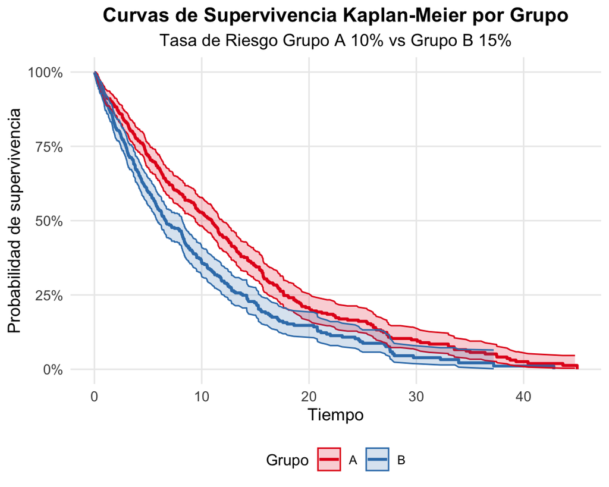

# Ejemplo Análisis Supervivencia Global

### **Análisis Supervivencia con el dataset *Melanom***

| status | days | ulc | thick | sex |
| --- | --- | --- | --- | --- |
| Muerte por melanoma | 10 | No ulcerado | 676 | Mujer |
| Muerte por melanoma | 30 | Ulcerado | 65 | Mujer |
| Censurado | 35 | Ulcerado | 134 | Mujer |
| Muerte por melanoma | 99 | Ulcerado | 290 | Hombre |
| Censurado | 185 | No ulcerado | 1208 | Mujer |
| Censurado | 204 | No ulcerado | 484 | Mujer |
| Censurado | 210 | No ulcerado | 516 | Mujer |
| Censurado | 232 | No ulcerado | 1288 | Mujer |
| Muerte por melanoma | 232 | No ulcerado | 322 | Hombre |
| Censurado | 279 | No ulcerado | 741 | Hombre |
| Censurado | 295 | No ulcerado | 419 | Hombre |
| Muerte por melanoma | 355 | No ulcerado | 16 | Hombre |
| Censurado | 386 | No ulcerado | 387 | Hombre |
| Censurado | 426 | No ulcerado | 484 | Mujer |
| Censurado | 469 | No ulcerado | 242 | Hombre |
| Muerte por melanoma | 493 | No ulcerado | 1256 | Mujer |
| Censurado | 529 | No ulcerado | 580 | Mujer |
| Censurado | 621 | No ulcerado | 706 | Mujer |
| Censurado | 629 | No ulcerado | 548 | Mujer |
| Censurado | 659 | No ulcerado | 773 | Mujer |
| Censurado | 667 | No ulcerado | 1385 | Hombre |
| Censurado | 718 | No ulcerado | 234 | Mujer |
| Censurado | 752 | No ulcerado | 419 | Mujer |
| Censurado | 779 | No ulcerado | 404 | Mujer |
| Censurado | 793 | No ulcerado | 484 | Mujer |
| Censurado | 817 | Ulcerado | 32 | Hombre |
| Muerte por melanoma | 826 | No ulcerado | 854 | Hombre |
| Censurado | 833 | No ulcerado | 258 | Hombre |
| Censurado | 858 | Ulcerado | 356 | Hombre |
| Censurado | 869 | Ulcerado | 354 | Hombre |

[output cut: 175 more lines]

El dataset *melanom* contiene información sobre pacientes con melanoma:

- **no**: Identificador único del paciente
- **status**: Variable que indica el estado del paciente:
  - 1 = Muerte por otras causas (censurado)
  - 2 = Vivo (censurado)
  - 3 = Muerte por melanoma (evento)
- **days**: Tiempo de supervivencia en días desde el diagnóstico hasta:
  - La muerte por melanoma
  - La censura (muerte por otras causas o fin del seguimiento)
- **ulc**: Presencia o ausencia de ulceración en el tumor. Variable binaria:
  - 1 = No ulcerado
  - 2 = Ulcerado
- **thick**: Grosor del tumor en milésimas de milímetro
- **sex**: Sexo del paciente. Variable binaria:
  - 1 = Hombre
  - 2 = Mujer

### **Análisis de Supervivencia Global con Kaplan-Miller**

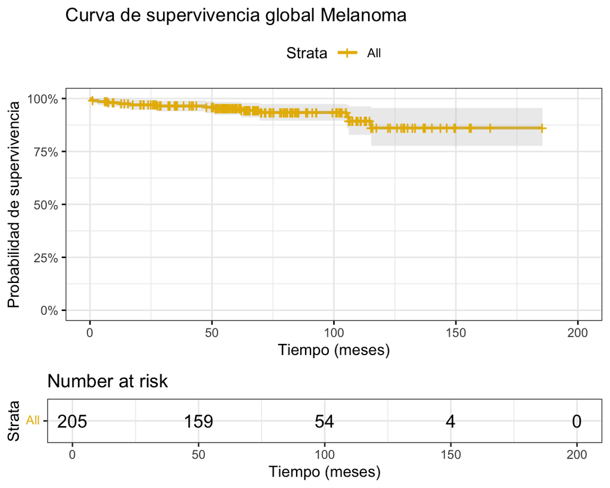

### **Análisis de los resultados**

**Conclusiones:**

- La curva se mantiene muy cercana al 100% durante los primeros 50 meses, lo que indica muy pocos eventos (muertes) en este período.
- Entre los 50 y 100 meses hay una ligera caída, pero es gradual y relativamente pequeña.
- La probabilidad de supervivencia se mantiene por encima del 75% durante todo el seguimiento, por lo que el pronóstico general parece favorable.

**Limitaciones del modelo:**

- La precisión de las estimaciones disminuye con el tiempo (intervalos de confianza más amplios)
- Pocos pacientes en seguimiento después de los 150 meses limita las conclusiones a largo plazo

# Ejemplo Análisis Supervivencia Univariable

### **Análisis Supervivencia Univariable**

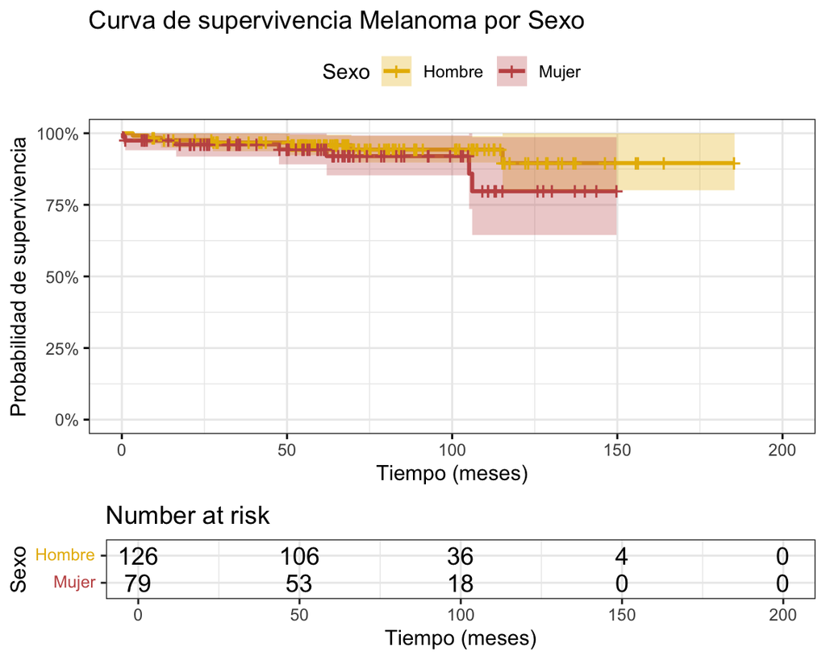

### **Modelo de Cox**

Con el modelo de Cox, modelamos el impacto de diferentes factores $X1,X2,...,Xq$ en la supervivencia a través de su impacto en la función de riesgo:

$$h(t|X) = h_0(t)\exp(\beta_1X_1 +
\beta_2X_2 + \cdots + \beta_qX_q)$$
donde:

- $h(t|X)$ es la tasa instantánea de muerte condicionada a haber sobrevivido hasta el tiempo t.
- $h0(t)$ es la función de riesgo subyacente. Describe cómo evoluciona el riesgo promedio de una persona a lo largo del tiempo.
- $exp(β1X1+β2X2+⋯+βqXq)$ describe cómo las covariables afectan al riesgo. En particular, un aumento de una unidad en xi conduce a un aumento del riesgo por un factor de exp(βi).

### **Análisis Regresión de Cox**

| Variable | HR | CI_lower | CI_upper | p_value |
| --- | --- | --- | --- | --- |
| Sexo (Mujer vs Hombre) | 1.88 | 0.66 | 5.37 | 0.24 |

- Riesgo en mujeres: Aunque el Hazard Ratio (HR) de 1.88 sugiere que las mujeres tienen un riesgo 88% mayor de morir por melanoma en comparación con los hombres, este resultado no es estadísticamente significativo.
- Incertidumbre: El intervalo de confianza (CI) amplio (0.66 - 5.37) y el valor p alto (0.24) indican que hay mucha incertidumbre en esta estimación. No podemos descartar que el verdadero HR sea incluso menor que 1 (lo que significaría un menor riesgo en mujeres).
- Conclusión: No hay evidencia suficiente para afirmar que el sexo femenino influya en la supervivencia en pacientes con melanoma según este estudio.

# Ejemplo Análisis Supervivencia Multi-variable

### **El conjunto de datos *Lung***

Utilizamos el **conjunto de datos lung** disponible en el paquete survival. Los datos contienen sujetos con cáncer de pulmón avanzado del North Central Cancer Treatment Group. Incluye las siguientes 10 variables:

- inst: Código de la institución
- time: Tiempo de supervivencia en días
- status: estado de censura 1=censurado, 2=fallecido
- age: Edad en años
- sex: Hombre=1 Mujer=2
- ph.ecog: Puntuación de rendimiento ECOG evaluada por el médico. 0=asintomático, 1=sintomático pero completamente ambulatorio, 2=en cama <50% del día, 3=en cama >50% del día pero no postrado, 4=postrado
- ph.karno: Puntuación de rendimiento Karnofsky (malo=0-bueno=100) evaluada por el médico
- pat.karno: Puntuación de rendimiento Karnofsky (0=malo, 100=bueno) evaluada por el paciente
- meal.cal: Calorías consumidas en las comidas
- wt.loss: Pérdida de peso en los últimos seis meses

### **Regresión Cox Multivariable**

Este análisis considera el efecto conjunto de las variables, lo que significa que los resultados están ajustados por las otras variables en el modelo.

| Variables | HR | CI_lower | CI_upper | p_value |
| --- | --- | --- | --- | --- |
| age | 1.02 | 1.00 | 1.05 | 0.0974 |
| sex2 | 6.91 | 0.42 | 114.24 | 0.1766 |
| ph.ecog1 | 2.00 | 1.15 | 3.48 | 0.0142 |
| ph.ecog2 | 4.81 | 1.97 | 11.77 | 0.0006 |
| ph.ecog3 | 16.51 | 1.83 | 148.83 | 0.0125 |
| ph.karno | 1.02 | 1.00 | 1.05 | 0.0312 |
| pat.karno | 0.99 | 0.97 | 1.00 | 0.0956 |
| meal.cal | 1.00 | 1.00 | 1.00 | 0.8952 |
| wt.loss | 0.98 | 0.97 | 1.00 | 0.0404 |
| age:sex2 | 0.96 | 0.92 | 1.00 | 0.0818 |

### **Análisis Resultados Regresión Cox Multivariable**

El modelo en su conjunto es estadísticamente significativo (2.45^{-4}), lo que indica que las variables incluidas en el modelo (ph.ecog, ph.karno, wt.loss) en conjunto tienen un efecto significativo en la supervivencia.

El estado funcional del paciente (medido con la escala ph.ecog) es el factor más importante en este modelo para predecir la supervivencia.